# LDA_OB

1. Import the necessary packages

```r
library(klaR)
library(tidyverse)
library(caret)
library(MASS)
library(scales)
theme_set(theme_classic())
```

2. Import the training dataset and clean

```r
beers_train <- read.table("C:/Users/Oisin/Desktop/ML Assignment 1/Data/beer_training.txt")

colnames(beers_train) <- c('calorific_value', 'nitrogen', 'turbidity', 'style', 'alcohol', 'sugars', 'bitterness', 'beer_id', 'colour', 'degree_of_fermentation')

rownames(beers_train) <- beers_train$beer_id

beers_train <- arrange(beers_train,by=style)

beers_train <- beers_train %>% relocate(style)

beers_train <- subset(beers_train, select = -c(beer_id))

beers_train
```

|  | style | calorific_value | nitrogen | turbidity | alcohol | sugars | bitterness | colour | degree_of_fermentation |
| --- | --- | --- | --- | --- | --- | --- | --- | --- | --- |
| 1 | ale | 45.30531 | 0.4595482 | 1.9172727 | 4.227692 | 16.67 | 12.568947 | 11.040 | 62.17857 |
| 2 | ale | 43.88938 | 0.5489770 | 3.1863636 | 4.289231 | 16.73 | 14.974000 | 13.440 | 63.03286 |
| 3 | ale | 41.58850 | 0.5428470 | 1.5681818 | 4.344615 | 16.48 | 11.848789 | 14.040 | 63.46857 |
| 4 | ale | 44.55310 | 0.4803009 | 1.8718182 | 4.424615 | 18.59 | 13.879632 | 12.480 | 63.53143 |
| 5 | ale | 41.01327 | 0.4418605 | 2.3454545 | 4.264615 | 16.35 | 12.186053 | 12.120 | 63.74714 |
| 6 | ale | 42.78319 | 0.3604634 | 1.8890909 | 4.172308 | 16.71 | 15.093737 | 11.400 | 63.91286 |
| 7 | ale | 44.77434 | 0.4319595 | 1.1418182 | 4.218462 | 16.86 | 12.822737 | 13.320 | 64.03429 |
| 8 | ale | 44.15487 | 0.4934468 | 2.4436364 | 4.252308 | 16.75 | 14.172947 | 12.120 | 65.62571 |
| 9 | ale | 37.60619 | 0.4854801 | 2.5545455 | 4.338462 | 17.02 | 13.262526 | 12.840 | 65.82857 |
| 10 | ale | 45.83628 | 0.5208624 | 1.8863636 | 4.230769 | 16.73 | 11.503368 | 13.800 | 66.47000 |

[output cut: 114 more lines]

3. Import the test dataset and clean

```r
beers_test <- read.table("C:/Users/Oisin/Desktop/ML Assignment 1/Data/beer_test.txt")

colnames(beers_test) <- c('calorific_value', 'nitrogen', 'turbidity', 'style', 'alcohol', 'sugars', 'bitterness', 'beer_id', 'colour', 'degree_of_fermentation')

rownames(beers_test) <- beers_test$beer_id

beers_test <- arrange(beers_test,by=style)

beers_test <- beers_test %>% relocate(style)

beers_test <- subset(beers_test, select = -c(beer_id))

beers_test
```

|  | style | calorific_value | nitrogen | turbidity | alcohol | sugars | bitterness | colour | degree_of_fermentation |
| --- | --- | --- | --- | --- | --- | --- | --- | --- | --- |
| 1 | ale | 41.72124 | 0.5032758 | 2.6281818 | 4.015385 | 16.73 | 10.452789 | 13.44 | 55.33714 |
| 2 | ale | 42.42920 | 0.5255122 | 1.7763636 | 4.092308 | 16.72 | 10.999526 | 12.24 | 58.38000 |
| 3 | ale | 45.88053 | 0.4432328 | 2.6281818 | 4.276923 | 16.68 | 13.456368 | 10.92 | 58.38286 |
| 4 | ale | 45.30531 | 0.4716678 | 1.8063636 | 4.126154 | 18.84 | 9.202737 | 10.92 | 58.52571 |
| 5 | ale | 38.97788 | 0.3928458 | 2.2727273 | 4.015385 | 16.77 | 9.457895 | 10.56 | 58.90000 |
| 6 | ale | 41.14602 | 0.3964436 | 0.8854545 | 4.021538 | 16.50 | 13.026105 | 14.16 | 59.41429 |
| 7 | ale | 45.39381 | 0.4661716 | 1.9809091 | 4.563077 | 16.64 | 11.448526 | 12.96 | 60.01857 |
| 8 | ale | 38.26991 | 0.4724782 | 2.0990909 | 4.313846 | 16.68 | 12.328263 | 12.48 | 60.35571 |
| 9 | ale | 43.53540 | 0.4358709 | 1.3427273 | 4.061538 | 16.78 | 10.819158 | 12.60 | 60.46571 |
| 10 | ale | 37.29646 | 0.3678972 | 2.1045455 | 4.326154 | 16.63 | 13.300684 | 13.08 | 61.84571 |

[output cut: 20 more lines]

4. Apply a preprocessing technique to my data to get it ready for LDA: “center“: subtract mean from values. “scale“: divide values by standard deviation.

```r
preproc.param <- beers_train %>%
  preProcess(method = c("center", "scale"))
# Transform the data using the estimated parameters
train.transformed <- preproc.param %>% predict(beers_train)
test.transformed <- preproc.param %>% predict(beers_test)
```

```r
train.transformed
```

|  | style | calorific_value | nitrogen | turbidity | alcohol | sugars | bitterness | colour | degree_of_fermentation |
| --- | --- | --- | --- | --- | --- | --- | --- | --- | --- |
| 1 | ale | 1.39766656 | 1.01655822 | 0.06541696 | 0.914994066 | -0.624659371 | 1.06246500 | -0.09892468 | -0.846871405 |
| 2 | ale | 0.85802066 | 1.67882345 | 1.48820089 | 1.160656647 | -0.570781957 | 1.76571032 | 0.74530518 | -0.701162113 |
| 3 | ale | -0.01890392 | 1.63342736 | -0.32595054 | 1.381752975 | -0.795271182 | 0.85188846 | 0.95636264 | -0.626845499 |
| 4 | ale | 1.11097968 | 1.17024263 | 0.01445765 | 1.701114333 | 1.099417873 | 1.44571338 | 0.40761324 | -0.616124414 |
| 5 | ale | -0.23813507 | 0.88557186 | 0.54545366 | 1.062391617 | -0.912005579 | 0.95050532 | 0.28097876 | -0.579331599 |
| 6 | ale | 0.43642230 | 0.28278591 | 0.03382219 | 0.693897739 | -0.588741095 | 1.80072176 | 0.02770980 | -0.551066921 |
| 7 | ale | 1.19529935 | 0.81225045 | -0.80394886 | 0.878144676 | -0.454047561 | 1.13667388 | 0.70309369 | -0.530355734 |
| 8 | ale | 0.95920427 | 1.26759427 | 0.65552577 | 1.013259097 | -0.552822819 | 1.53147989 | 0.28097876 | -0.258917349 |
| 9 | ale | -1.53665802 | 1.20859712 | 0.77986649 | 1.357186713 | -0.310374457 | 1.26526977 | 0.53424771 | -0.224317484 |
| 10 | ale | 1.60003378 | 1.47062060 | 0.03076463 | 0.927277195 | -0.570781957 | 0.75088620 | 0.87193966 | -0.114913684 |

[output cut: 114 more lines]

```r
test.transformed
```

|  | style | calorific_value | nitrogen | turbidity | alcohol | sugars | bitterness | colour | degree_of_fermentation |
| --- | --- | --- | --- | --- | --- | --- | --- | --- | --- |
| 1 | ale | 0.03168788 | 1.34038280 | 0.86242057 | 0.06745815 | -0.5707820 | 0.443693455 | 0.74530518 | -2.0137641 |
| 2 | ale | 0.30151083 | 1.50505464 | -0.09255690 | 0.37453638 | -0.5797615 | 0.603561112 | 0.32319025 | -1.4947661 |
| 3 | ale | 1.61689771 | 0.89573460 | 0.86242057 | 1.11152413 | -0.6156798 | 1.321949840 | -0.14113617 | -1.4942788 |
| 4 | ale | 1.39766656 | 1.10631002 | -0.05892375 | 0.50965080 | 1.3239071 | 0.078173947 | -0.14113617 | -1.4699126 |
| 5 | ale | -1.01387606 | 0.52259347 | 0.46391877 | 0.06745815 | -0.5348637 | 0.152782956 | -0.26777065 | -1.4060735 |
| 6 | ale | -0.18754327 | 0.54923734 | -1.09135937 | 0.09202441 | -0.7773120 | 1.196139474 | 0.99857413 | -1.3183555 |
| 7 | ale | 1.43139443 | 1.06560832 | 0.13676000 | 2.25385514 | -0.6515981 | 0.734850192 | 0.57645921 | -1.2152869 |
| 8 | ale | -1.28369901 | 1.11231123 | 0.26925420 | 1.25892168 | -0.6156798 | 0.992088144 | 0.40761324 | -1.1577829 |
| 9 | ale | 0.72310919 | 0.84121615 | -0.57870871 | 0.25170509 | -0.5258841 | 0.550820789 | 0.44982473 | -1.1390210 |
| 10 | ale | -1.65470556 | 0.33783723 | 0.27536932 | 1.30805420 | -0.6605776 | 1.276427264 | 0.61867070 | -0.9036444 |

[output cut: 20 more lines]

5. Fit the model to the transformed data and look at the predictions on the test set

```r
# Fit the model
model <- lda(style~., data = train.transformed)
# Make predictions
predictions <- model %>% predict(test.transformed)
```

```r
model
```

```
## Call:
## lda(style ~ ., data = train.transformed)
##
## Prior probabilities of groups:
##       ale     lager     stout
## 0.3387097 0.3548387 0.3064516
##
## Group means:
##       calorific_value   nitrogen   turbidity    alcohol     sugars
## ale        0.06300661  1.1381186  0.07514776  0.9155790 -0.3127262
## lager     -0.17182915 -0.7624341 -0.87739976 -0.9774453 -0.5003740
## stout      0.12932118 -0.3751021  0.93287851  0.1198231  0.9250252
##        bitterness     colour degree_of_fermentation
## ale    0.86329768  0.5000765              0.4972208
## lager  0.03597728  0.5031647             -0.1898339
## stout -0.99582903 -1.1353279             -0.3297522
##
## Coefficients of linear discriminants:
##                                LD1         LD2
## calorific_value        -0.02880087  0.06814431
## nitrogen               -0.82797931  0.85051275
## turbidity               0.69967744  0.50491692
## alcohol                -0.31313101  0.94486221
## sugars                  0.33425179  0.23847579
## bitterness             -0.98852273 -0.31520076
## colour                 -0.58409941 -0.43812625
## degree_of_fermentation -0.06004528  0.29024988
##
## Proportion of trace:
##    LD1    LD2
## 0.5864 0.4136
```

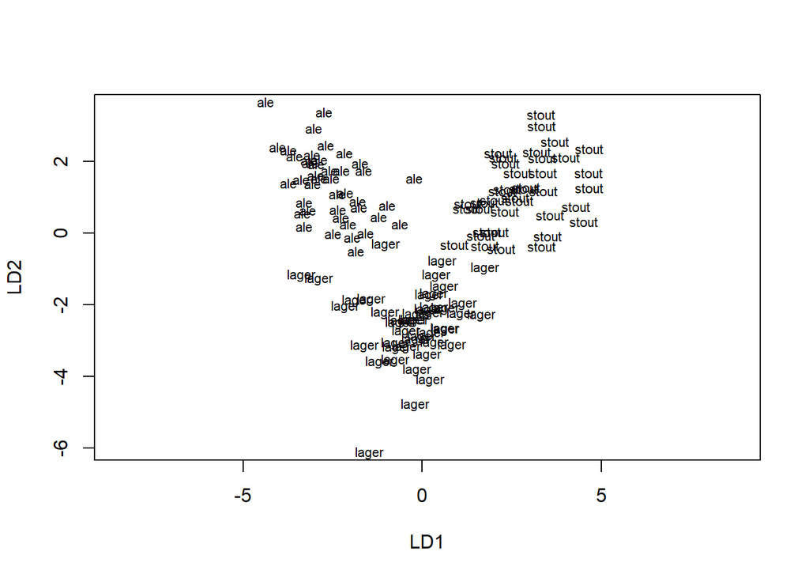

```r
plot(model)
```

6. Linear discriminants are calculated by the prediction and are the result on dimensionality reduction on the feature attributes

```r
# Predicted classes
(predictions$class)
```

```
##  [1] ale   ale   ale   ale   ale   ale   ale   ale   ale   ale   lager
## [12] lager lager lager lager lager lager lager lager lager stout stout
## [23] stout stout stout stout stout stout stout stout
## Levels: ale lager stout
```

```r
# Predicted probabilities of class memebership.
(predictions$posterior)
```

```
##             ale        lager        stout
## 1  9.819117e-01 1.796124e-02 1.271054e-04
## 2  9.990278e-01 9.709113e-04 1.254089e-06
## 3  9.998192e-01 1.688323e-04 1.192988e-05
## 4  9.872715e-01 3.068984e-03 9.659546e-03
## 5  4.877489e-01 4.474219e-01 6.482927e-02
## 6  6.840280e-01 3.159720e-01 1.414997e-08
## 7  9.999988e-01 1.071163e-06 9.405656e-08
## 8  9.998959e-01 1.034813e-04 5.879625e-07
## 9  9.631623e-01 3.683316e-02 4.562891e-06
## 10 9.968964e-01 3.101521e-03 2.125641e-06
## 11 8.770259e-08 9.998910e-01 1.089384e-04
## 12 9.858199e-06 9.994680e-01 5.221067e-04
## 13 8.216540e-07 9.999989e-01 3.075908e-07
## 14 7.647696e-04 9.992350e-01 1.833401e-07
```

[output cut: 16 more lines]

```r
# Linear discriminants
predictions$x
```

```
##           LD1         LD2
## 1  -1.4722301  0.45435867
## 2  -2.3263186  0.70381031
## 3  -1.8732618  1.42232086
## 4  -0.6211304  1.41424476
## 5  -0.1890016  0.20685697
## 6  -3.1881055 -1.39229030
## 7  -2.7415423  2.21017535
## 8  -2.4448764  1.20985256
## 9  -2.1156879 -0.11634284
## 10 -2.2386702  0.45634453
## 11  1.3685462 -3.07379507
## 12  0.8200548 -2.18351797
## 13 -0.1598831 -3.40311461
## 14 -1.4884061 -2.43070913
```

[output cut: 16 more lines]

7. Look at the resulting plot of LD1 vs LD2

```r
predictions <- as.data.frame(predictions)

predictions
```

|  | class | posterior.ale | posterior.lager | posterior.stout | x.LD1 | x.LD2 |
| --- | --- | --- | --- | --- | --- | --- |
| 1 | ale | 9.819117e-01 | 1.796124e-02 | 1.271054e-04 | -1.4722301 | 0.45435867 |
| 2 | ale | 9.990278e-01 | 9.709113e-04 | 1.254089e-06 | -2.3263186 | 0.70381031 |
| 3 | ale | 9.998192e-01 | 1.688323e-04 | 1.192988e-05 | -1.8732618 | 1.42232086 |
| 4 | ale | 9.872715e-01 | 3.068984e-03 | 9.659546e-03 | -0.6211304 | 1.41424476 |
| 5 | ale | 4.877489e-01 | 4.474219e-01 | 6.482927e-02 | -0.1890016 | 0.20685697 |
| 6 | ale | 6.840280e-01 | 3.159720e-01 | 1.414997e-08 | -3.1881055 | -1.39229030 |
| 7 | ale | 9.999988e-01 | 1.071163e-06 | 9.405656e-08 | -2.7415423 | 2.21017535 |
| 8 | ale | 9.998959e-01 | 1.034813e-04 | 5.879625e-07 | -2.4448764 | 1.20985256 |
| 9 | ale | 9.631623e-01 | 3.683316e-02 | 4.562891e-06 | -2.1156879 | -0.11634284 |
| 10 | ale | 9.968964e-01 | 3.101521e-03 | 2.125641e-06 | -2.2386702 | 0.45634453 |

[output cut: 20 more lines]

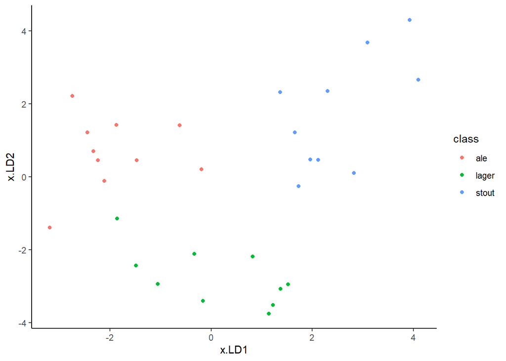

```r
ggplot(predictions, aes(x=x.LD1,y=x.LD2,color=class)) +
  geom_point()
```

8. Add LDA1 and LDA2 to our transformed training data

```r
lda.data <- cbind(train.transformed, predict(model)$x)

lda.data
```

|  | style | calorific_value | nitrogen | turbidity | alcohol | sugars | bitterness | colour | degree_of_fermentation | LD1 | LD2 |
| --- | --- | --- | --- | --- | --- | --- | --- | --- | --- | --- | --- |
| 1 | ale | 1.39766656 | 1.01655822 | 0.06541696 | 0.914994066 | -0.624659371 | 1.06246500 | -0.09892468 | -0.846871405 | -2.27311728 | 1.171093453 |
| 2 | ale | 0.85802066 | 1.67882345 | 1.48820089 | 1.160656647 | -0.570781957 | 1.76571032 | 0.74530518 | -0.701162113 | -3.06638034 | 2.111687477 |
| 3 | ale | -0.01890392 | 1.63342736 | -0.32595054 | 1.381752975 | -0.795271182 | 0.85188846 | 0.95636264 | -0.626845499 | -3.64153322 | 1.469832604 |
| 4 | ale | 1.11097968 | 1.17024263 | 0.01445765 | 1.701114333 | 1.099417873 | 1.44571338 | 0.40761324 | -0.616124414 | -2.78621925 | 2.134710256 |
| 5 | ale | -0.23813507 | 0.88557186 | 0.54545366 | 1.062391617 | -0.912005579 | 0.95050532 | 0.28097876 | -0.579331599 | -2.05117183 | 1.207838729 |
| 6 | ale | 0.43642230 | 0.28278591 | 0.03382219 | 0.693897739 | -0.588741095 | 1.80072176 | 0.02770980 | -0.551066921 | -2.40026497 | 0.062890997 |
| 7 | ale | 1.19529935 | 0.81225045 | -0.80394886 | 0.878144676 | -0.454047561 | 1.13667388 | 0.70309369 | -0.530355734 | -3.19865687 | 0.267541240 |
| 8 | ale | 0.95920427 | 1.26759427 | 0.65552577 | 1.013259097 | -0.552822819 | 1.53147989 | 0.28097876 | -0.258917349 | -2.78305146 | 1.619032292 |
| 9 | ale | -1.53665802 | 1.20859712 | 0.77986649 | 1.357186713 | -0.310374457 | 1.26526977 | 0.53424771 | -0.224317484 | -2.48883430 | 1.827328115 |
| 10 | ale | 1.60003378 | 1.47062060 | 0.03076463 | 0.927277195 | -0.570781957 | 0.75088620 | 0.87193966 | -0.114913684 | -2.96801210 | 1.463326603 |

[output cut: 114 more lines]

9. Check that the resulting plot is the same as above

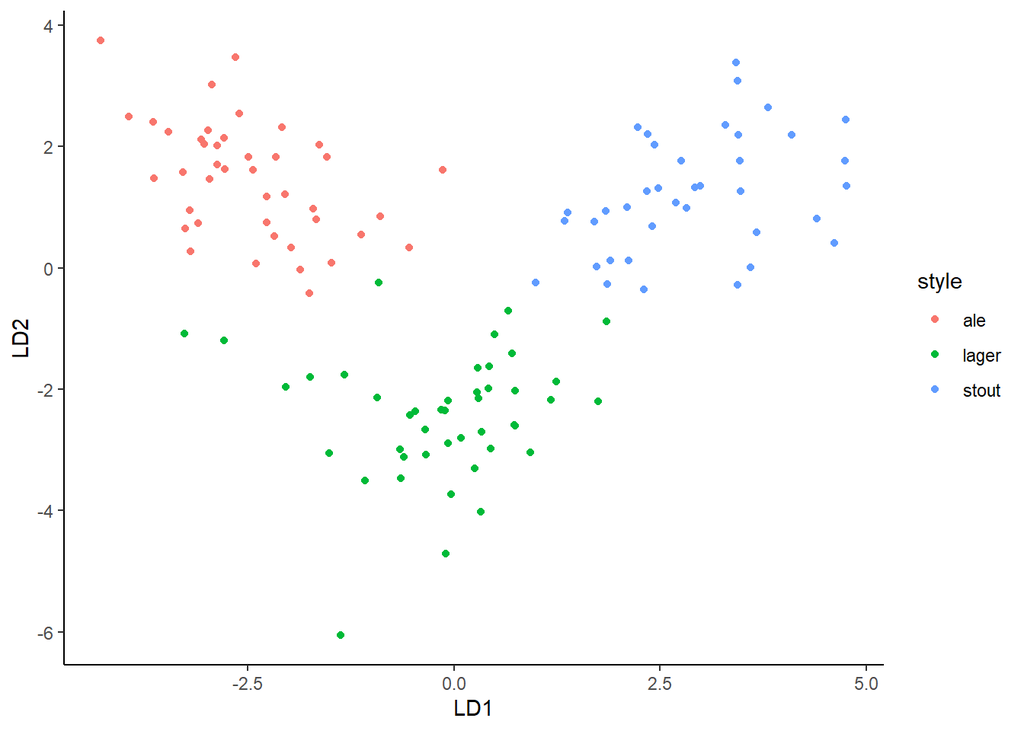

```r
ggplot(lda.data, aes(LD1, LD2)) +
  geom_point(aes(color = style))
```

```r
ggsave("LDA_OB.png")
```

10. Use the model to give a score for the accuracy on the test data - 100%

```r
mean(predictions$class==test.transformed$style)
```

```
## [1] 1
```

11. Look at the confusion matrix for the training & test data - note that it is 98% accurate while the test set is 100%

```r
beers.train.lda.predict <- train(style ~ ., method = "lda", data = train.transformed)
confusionMatrix(train.transformed$style, predict(beers.train.lda.predict, train.transformed))
```

```
## Confusion Matrix and Statistics
##
##           Reference
## Prediction ale lager stout
##      ale    42     0     0
##      lager   2    41     1
##      stout   0     0    38
##
## Overall Statistics
##
##                Accuracy : 0.9758
##                  95% CI : (0.9309, 0.995)
##     No Information Rate : 0.3548
##     P-Value [Acc > NIR] : < 2.2e-16
##
##                   Kappa : 0.9637
##
##  Mcnemar's Test P-Value : NA
##
## Statistics by Class:
##
##                      Class: ale Class: lager Class: stout
## Sensitivity              0.9545       1.0000       0.9744
## Specificity              1.0000       0.9639       1.0000
## Pos Pred Value           1.0000       0.9318       1.0000
## Neg Pred Value           0.9756       1.0000       0.9884
## Prevalence               0.3548       0.3306       0.3145
## Detection Rate           0.3387       0.3306       0.3065
## Detection Prevalence     0.3387       0.3548       0.3065
## Balanced Accuracy        0.9773       0.9819       0.9872
```

```r
beers.test.lda.predict <- train(style ~ ., method = "lda", data = beers_test)
confusionMatrix(beers_test$style, predict(beers.test.lda.predict, beers_test))
```

```
## Confusion Matrix and Statistics
##
##           Reference
## Prediction ale lager stout
##      ale    10     0     0
##      lager   0    10     0
##      stout   0     0    10
##
## Overall Statistics
##
##                Accuracy : 1
##                  95% CI : (0.8843, 1)
##     No Information Rate : 0.3333
##     P-Value [Acc > NIR] : 4.857e-15
##
##                   Kappa : 1
##
##  Mcnemar's Test P-Value : NA
##
## Statistics by Class:
##
##                      Class: ale Class: lager Class: stout
## Sensitivity              1.0000       1.0000       1.0000
## Specificity              1.0000       1.0000       1.0000
## Pos Pred Value           1.0000       1.0000       1.0000
## Neg Pred Value           1.0000       1.0000       1.0000
## Prevalence               0.3333       0.3333       0.3333
## Detection Rate           0.3333       0.3333       0.3333
## Detection Prevalence     0.3333       0.3333       0.3333
## Balanced Accuracy        1.0000       1.0000       1.0000
```

12. Plot the boundaries computed by LDA to visually see where the mistakes were made in the training data

```r
fit <- lda(style ~ ., data = train.transformed, prior = rep(1, 3)/3)
datPred <- data.frame(style=predict(fit)$class,predict(fit)$x)
#Create decision boundaries
fit2 <- lda(style ~ LD1 + LD2, data=datPred, prior = rep(1, 3)/3)
datPred <- datPred[-65,]
ld1lim <- expand_range(c(min(datPred$LD1),max(datPred$LD1)),mul=0.05)
ld2lim <- expand_range(c(min(datPred$LD2),max(datPred$LD2)),mul=0.05)
ld1 <- seq(ld1lim[[1]], ld1lim[[2]], length.out=300)
ld2 <- seq(ld2lim[[1]], ld1lim[[2]], length.out=300)
newdat <- expand.grid(list(LD1=ld1,LD2=ld2))
preds <-predict(fit2,newdata=newdat)
predclass <- preds$class
postprob <- preds$posterior
df <- data.frame(x=newdat$LD1, y=newdat$LD2, class=predclass)
df$classnum <- as.numeric(df$class)
df <- cbind(df,postprob)
```

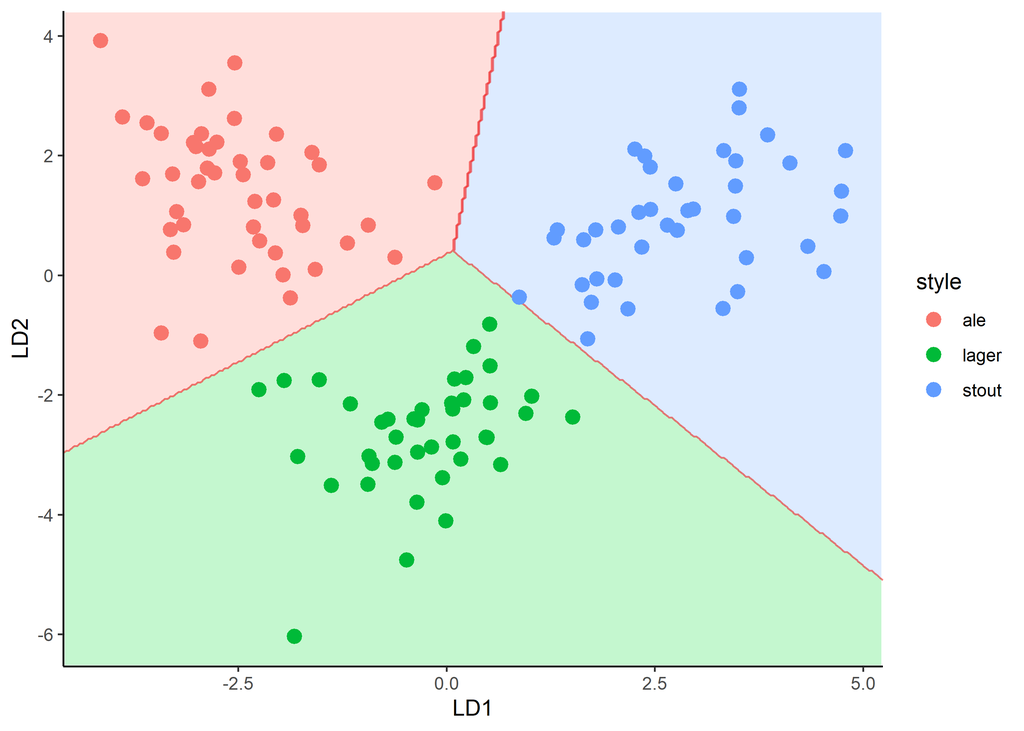

```r
colorfun <- function(n,l=65,c=100) { hues = seq(15, 375, length=n+1); hcl(h=hues, l=l, c=c)[1:n] } # default ggplot2 colours
colors <- colorfun(3)
colorslight <- colorfun(3,l=90,c=50)
ggplot(datPred, aes(x=LD1, y=LD2) ) +
    geom_raster(data=df, aes(x=x, y=y, fill = factor(class)),alpha=0.7,show_guide=FALSE) +
    geom_contour(data=df, aes(x=x, y=y, z=classnum), colour="red2", alpha=0.5, breaks=c(1.5,2.5)) +
    geom_point(data = datPred, size = 3, aes(colour=style)) +
    scale_x_continuous(limits = ld1lim, expand=c(0,0)) +
    scale_y_continuous(limits = ld2lim, expand=c(0,0)) +
    scale_fill_manual(values=colorslight,guide=F)
```

```r
ggsave("LDA_OB1.png")
```

13. Plot a similar graph for the test data

```r
fit <- lda(style ~ ., data = test.transformed, prior = rep(1, 3)/3)
datPred <- data.frame(style=predict(fit)$class,predict(fit)$x)
#Create decision boundaries
fit2 <- lda(style ~ LD1 + LD2, data=datPred, prior = rep(1, 3)/3)
ld1lim <- expand_range(c(min(datPred$LD1),max(datPred$LD1)),mul=0.05)
ld2lim <- expand_range(c(min(datPred$LD2),max(datPred$LD2)),mul=0.05)
ld1 <- seq(ld1lim[[1]], ld1lim[[2]], length.out=300)
ld2 <- seq(ld2lim[[1]], ld1lim[[2]], length.out=300)
newdat <- expand.grid(list(LD1=ld1,LD2=ld2))
preds <-predict(fit2,newdata=newdat)
predclass <- preds$class
postprob <- preds$posterior
df <- data.frame(x=newdat$LD1, y=newdat$LD2, class=predclass)
df$classnum <- as.numeric(df$class)
df <- cbind(df,postprob)
datPred
```

|  | style | LD1 | LD2 |
| --- | --- | --- | --- |
| 1 | ale | -2.8530990 | 3.1577613 |
| 2 | ale | -1.8509325 | 4.5232157 |
| 3 | ale | -2.6856989 | 2.7388200 |
| 4 | ale | -1.2457266 | 2.7321449 |
| 5 | ale | -0.6183876 | 2.0761018 |
| 6 | ale | -2.7637474 | 2.3081922 |
| 7 | ale | -0.9957294 | 3.4553289 |
| 8 | ale | -0.8460303 | 4.2781295 |
| 9 | ale | -1.4419561 | 2.6943110 |
| 10 | ale | -0.7847103 | 2.3048732 |

[output cut: 20 more lines]

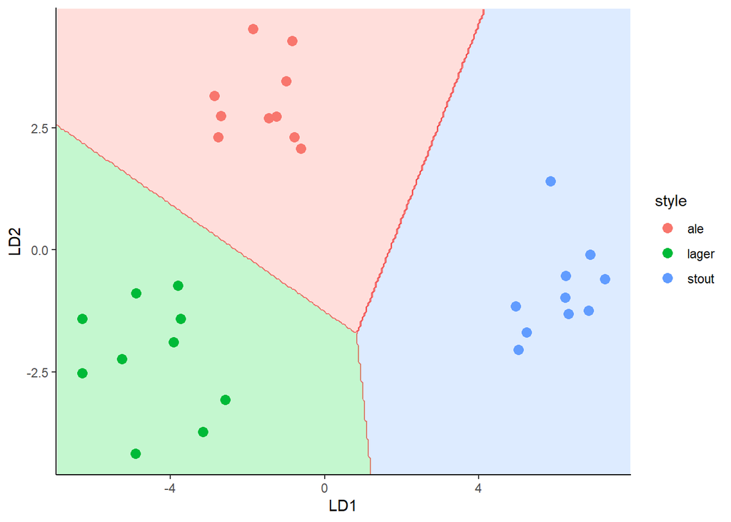

```r
colorfun <- function(n,l=65,c=100) { hues = seq(15, 375, length=n+1); hcl(h=hues, l=l, c=c)[1:n] } # default ggplot2 colours
colors <- colorfun(3)
colorslight <- colorfun(3,l=90,c=50)
ggplot(datPred, aes(x=LD1, y=LD2) ) +
    geom_raster(data=df, aes(x=x, y=y, fill = factor(class)),alpha=0.7,show_guide=FALSE) +
    geom_contour(data=df, aes(x=x, y=y, z=classnum), colour="red2", alpha=0.5, breaks=c(1.5,2.5)) +
    geom_point(data = datPred, size = 3, aes(colour=style)) +
    scale_x_continuous(limits = ld1lim, expand=c(0,0)) +
    scale_y_continuous(limits = ld2lim, expand=c(0,0)) +
    scale_fill_manual(values=colorslight,guide=F)
```

```r
ggsave("LDA_TEST_OB.png")
```